# R in Insurance

[figure not shown]

22 October 2015

## Agenda

- Introduction to R
- Mortality Overview
- Mortality Models
  - Classical
  - Stochastic
- Workshop: Stochastic Mortality Models in R
  - Models Fitting
  - Mortality Projection - Forecasting
  - Portfolio Analysis of BEL and SCR
- Case Studies

## What is R?

[video not shown]

## R Highlights

- **Free, open source, community** based statistical software and programming language
- Main usage: Statistical and numerical computing, Data Analysis, Data Visualisation
- Under GNU GPL (General Public License) allowing commercial usage
- Power of R in its **packages**

**“Everything that exists [in R] is an object. Everything that happens [in R] is a function call.”** - John Chambers

## RStudio

**Most popular Environment to run R**

http://www.rstudio.com/products/rstudio/

Free & Open-Source Integrated Development Environment (IDE) for R

**Features:**

1. Built-in R console
2. R, LaTeX, HTML, C++ syntax highlighting, R code completion
3. Easy management of multiple projects
4. Integrated R documentation
5. Interactive debugger
6. Package development tools

Note: R must be installed first!

## Playing with R

Type in the interactive console:

```r
3 + 3
```

```
## [1] 6
```

```r
getwd()
```

```
## [1] "C:/Users/omierzwa/Documents/GitHub/Insurance"
```

```r
1:10
```

```
##  [1]  1  2  3  4  5  6  7  8  9 10
```

## Playing with R

Type in the interactive console:

```r
x <- 1:10 # "name <- value returns the value invisibly"
```

```r
x
```

```
##  [1]  1  2  3  4  5  6  7  8  9 10
```

```r
(x <- 1:10) # creates x and prints it
```

```
##  [1]  1  2  3  4  5  6  7  8  9 10
```

## Operations in R

`x + y` addition

`x - y` substraction

`x * y` multiplication

`x / y` division

`x ^ y` exponention

`x %% y` devision remainder

`x %/% y` integer division

numeric vector `operator` numeric vector –> numeric vector

## Vectors

```r
(x <- 11:20) # exemplary vector
```

```
##  [1] 11 12 13 14 15 16 17 18 19 20
```

```r
x[1] # first
```

```
## [1] 11
```

```r
x[length(x)] # last element using length function
```

```
## [1] 20
```

```r
x[c(1, length(x), 1)] # first, last and first again
```

```
## [1] 11 20 11
```

## Vectors

```r
x[1000] # no such element
```

```
## [1] NA
```

```r
x * 3 # multiplication
```

```
##  [1] 33 36 39 42 45 48 51 54 57 60
```

```r
y <- 1:10
x * y
```

```
##  [1]  11  24  39  56  75  96 119 144 171 200
```

## R in Insurance

- Main focus Non-life
  - fit loss distributions and perform credibility analysis - package **actuar**
  - estimate loss reserves - package **ChainLadder**
- Financial analysis
  - packages **YieldCurve**, **termstrc**
- Life insurance
  - handle demography data - package **demography**
  - demography projections - package **LifeTables**
  - actuarial and financial mathematics - package **lifecontingencies**
  - Life models - packages **ilc**, **LifeMetrics**, **StMoMo**

## .

**Mortality Overview**

## Mortality Overview

Basic quantities in the analysis of mortality

- Survival function

\(s_{x} = Pr (X > x)\)

- Probability that (x) will survive for another t

\(p_{xt} = s_{x+t}/s_{x}\)

- Probability that (x) will die within t years

\(q_{xt} = [s_{x} - s_{x+t}]/s_{x}\)

- Mortality intensity (hazard function or force of mortality)

\(\mu_{x} = lim_{h \to 0} 1/h * q_{xh}\)

Probability that (x) will die within h

## Mortality Features

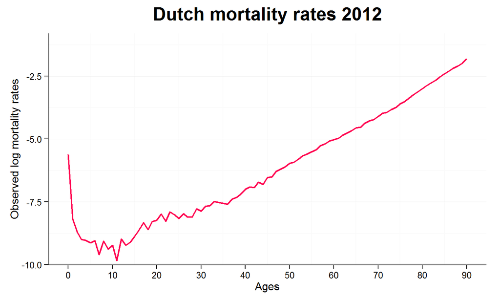

## Mortality Features

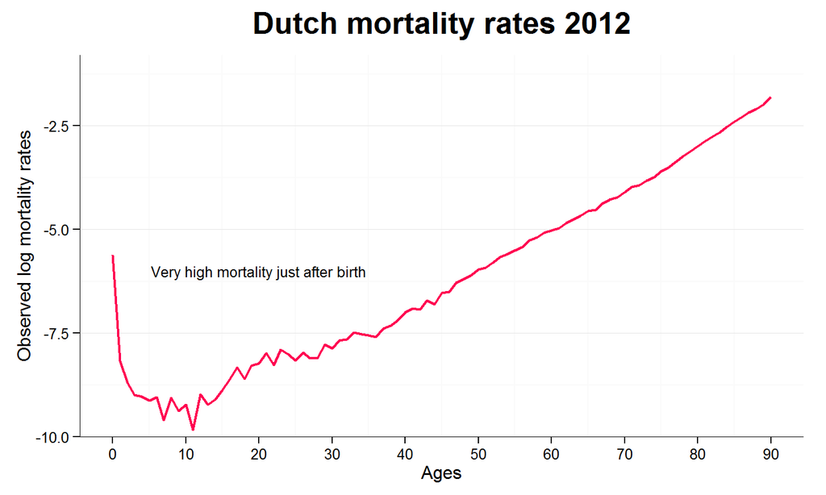

## Mortality Features

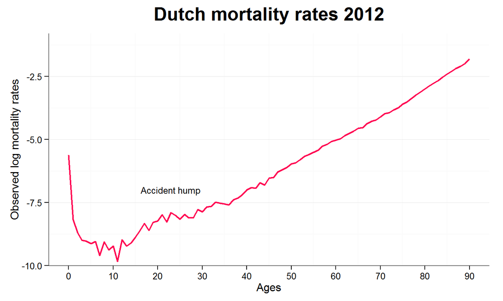

## Mortality Features

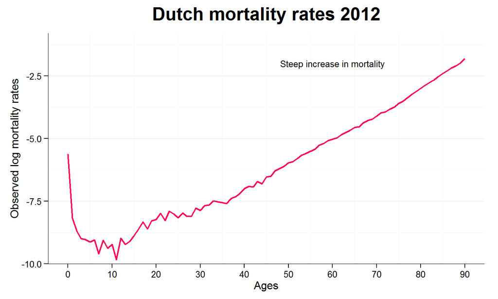

## .

**Mortality Models**

## Mortality Models

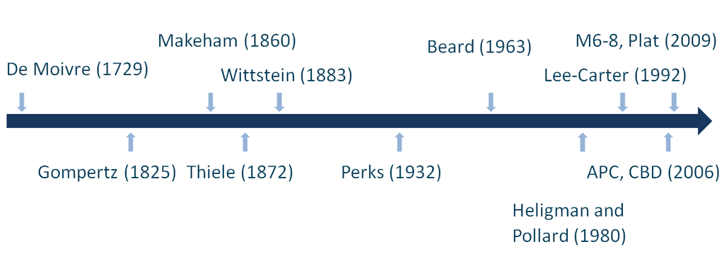

## Classic Models

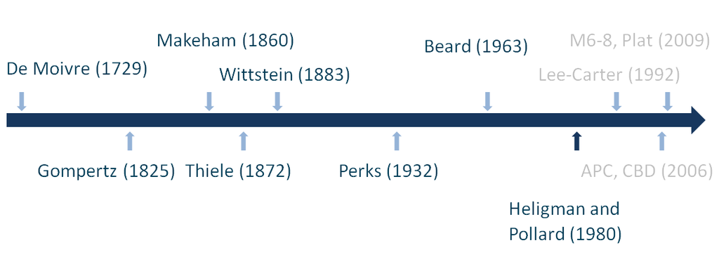

## Classic Models

**Some special parametric laws of mortality**

- De Moivre

\(\mu_{x} = 1/ (ω – x)\) subject to \(0 \leq x < ω\)

- Gompertz

\(\mu_{x} = Bc^{x}\) subject to \(x \geq 0, B>0, c>1\)

- Makeham

\(\mu_{x} = A + Bc^{x}\) subject to \(x \geq 0, B>0, c>1, A>=-B\)

- Thiele

\(\mu_{x} = B_{1}C_{1}^{-x}+B_{2}C_{2}^{[-1/2(x-k)^2]}+B_{3}C_{3}^{x}\) subject to \(x\geq 0, B_{1}, B_{2}, B_{3}>0, C_{1}, C_{2}, C_{3}>1\)

## Classic Models

**Advantages:**

- Compact, small numbers of parameters
- Highly interpretable
- Good for comparative work

**Disadvantages:**

- Almost certainly “wrong”
- Too simplistic
- Struggle with a new source of mortality

## Stochastic Models

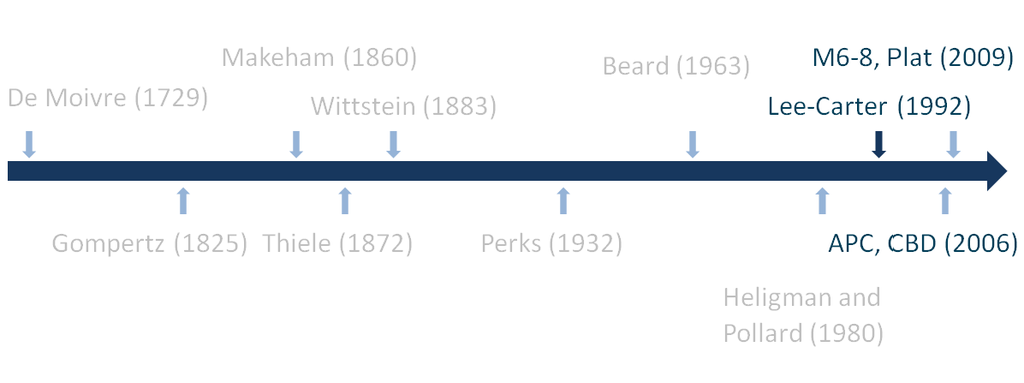

## Stochastic Models

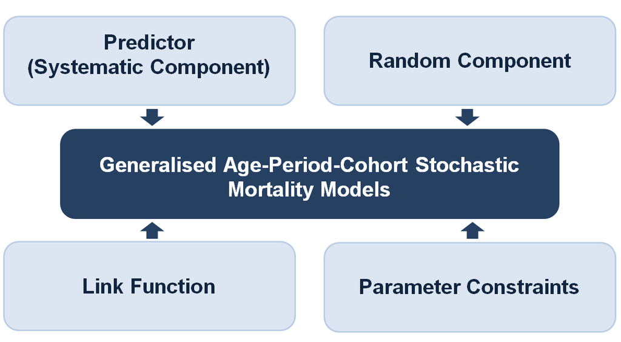

## Predictor

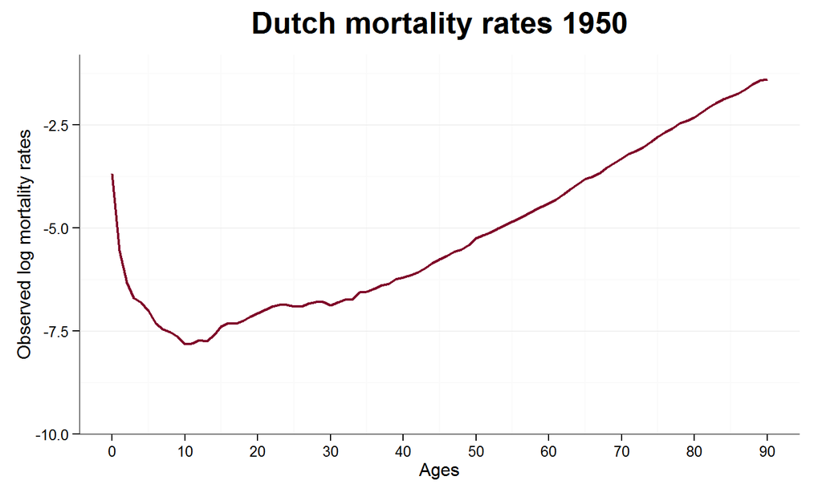

## Predictor

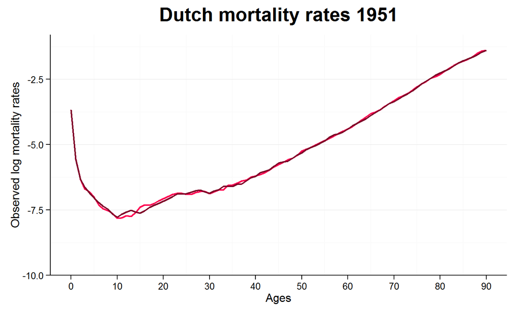

## Predictor

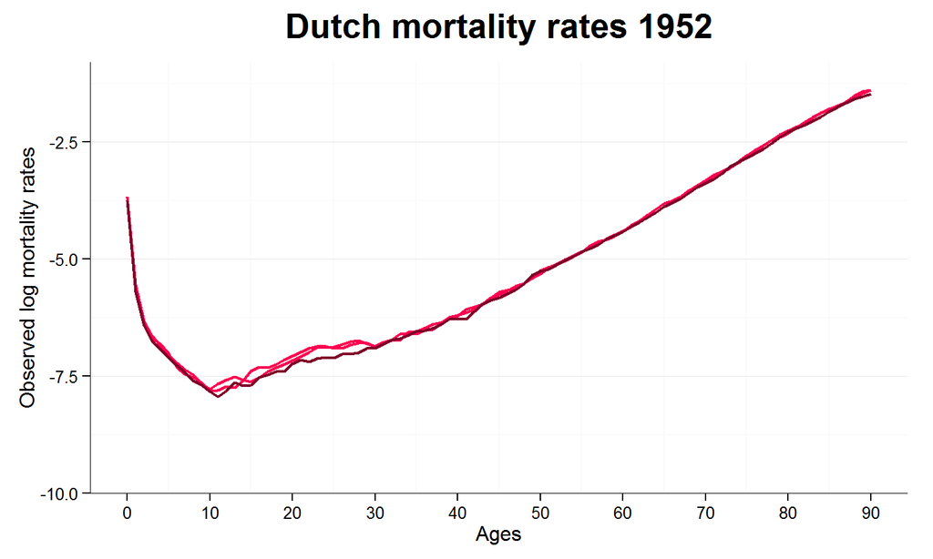

## Predictor

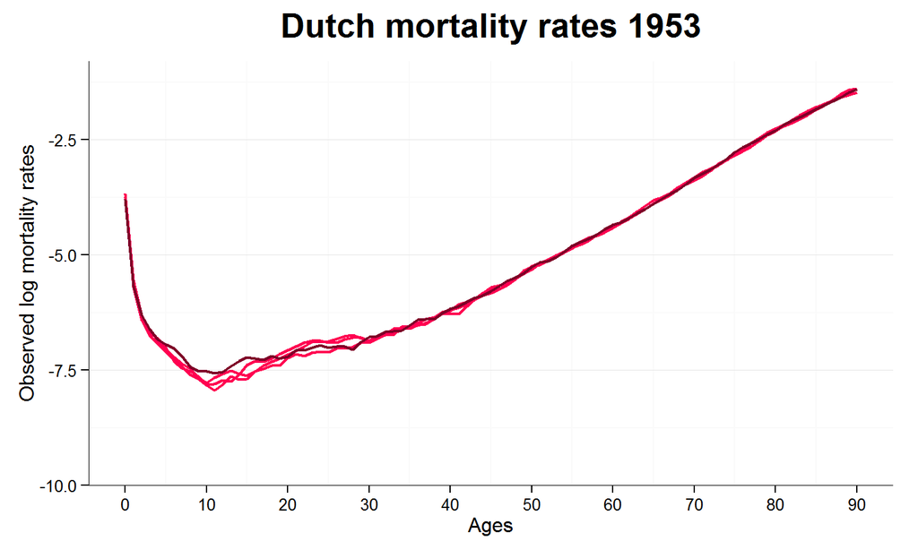

## Predictor

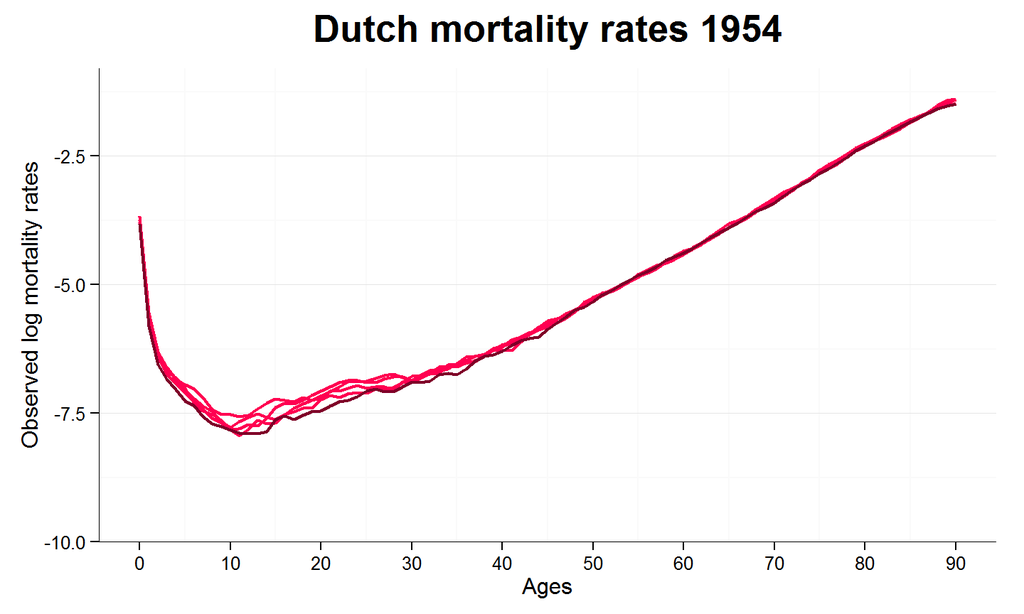

## Predictor

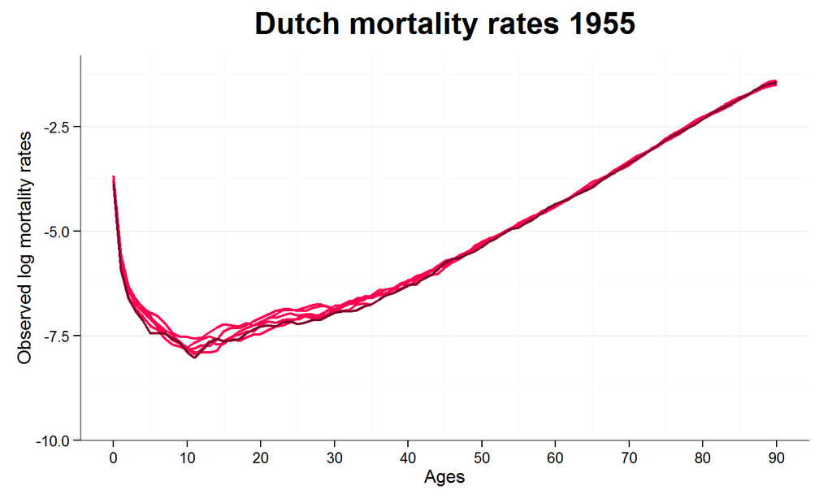

## Predictor

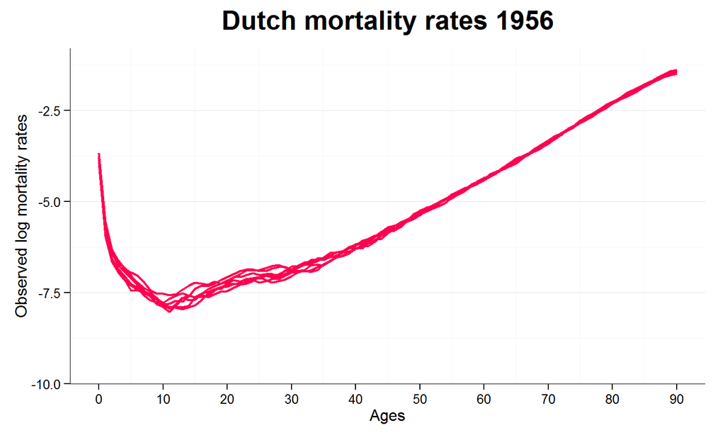

## Predictor

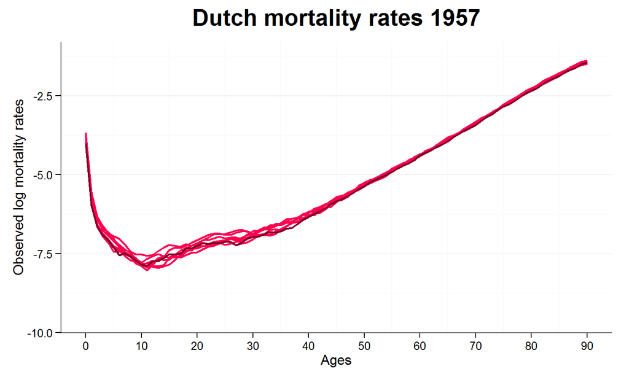

## Predictor

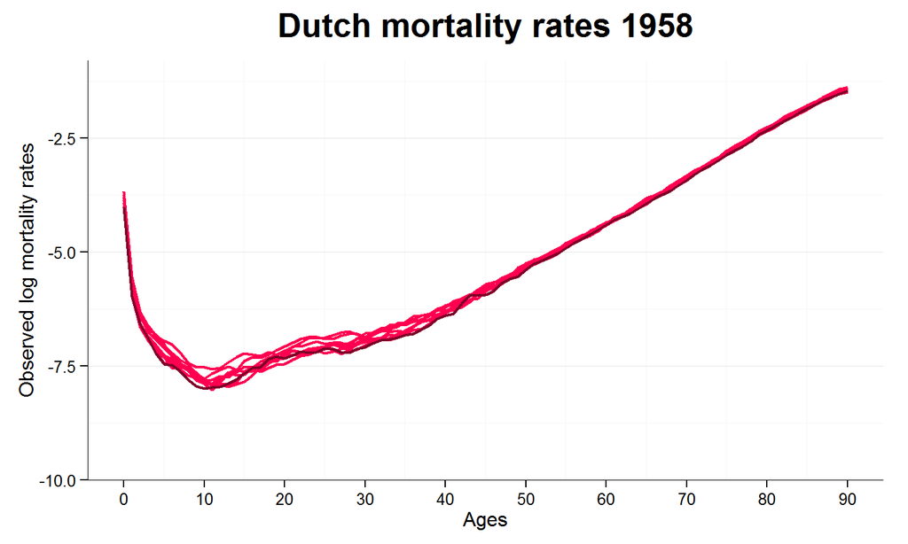

## Predictor

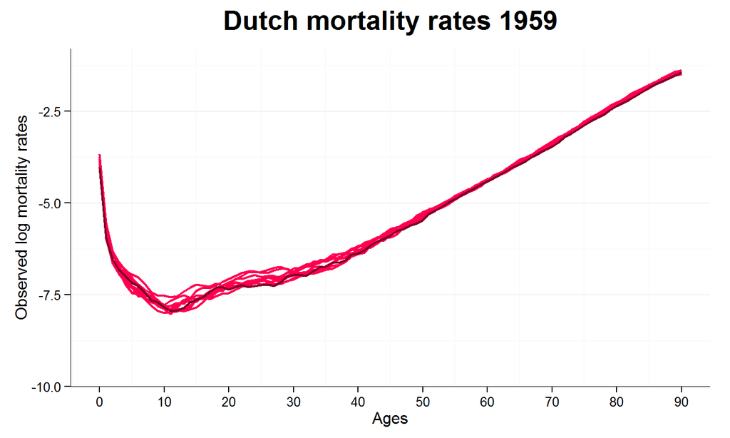

## Predictor

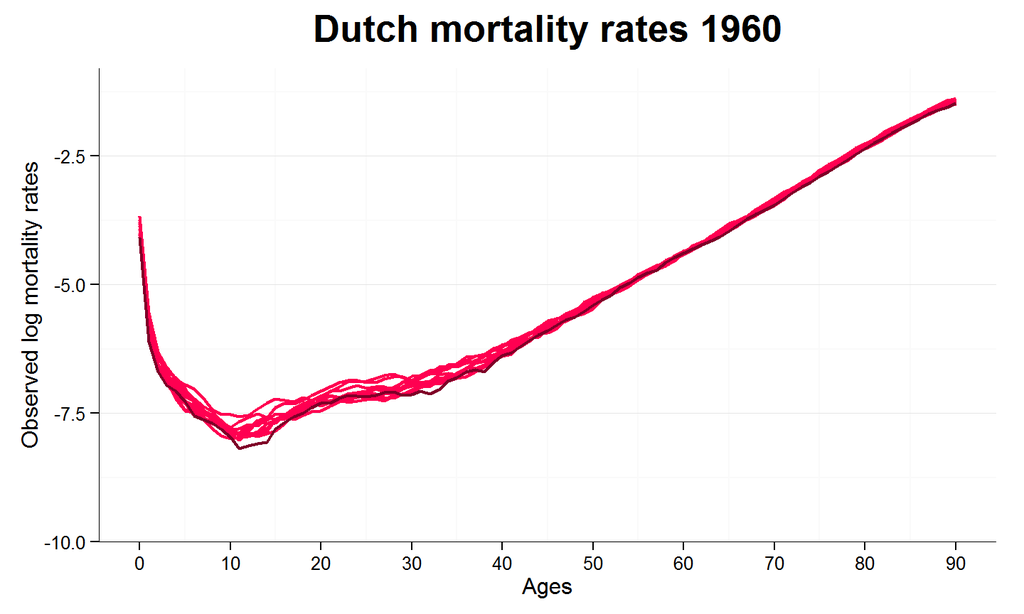

## Predictor

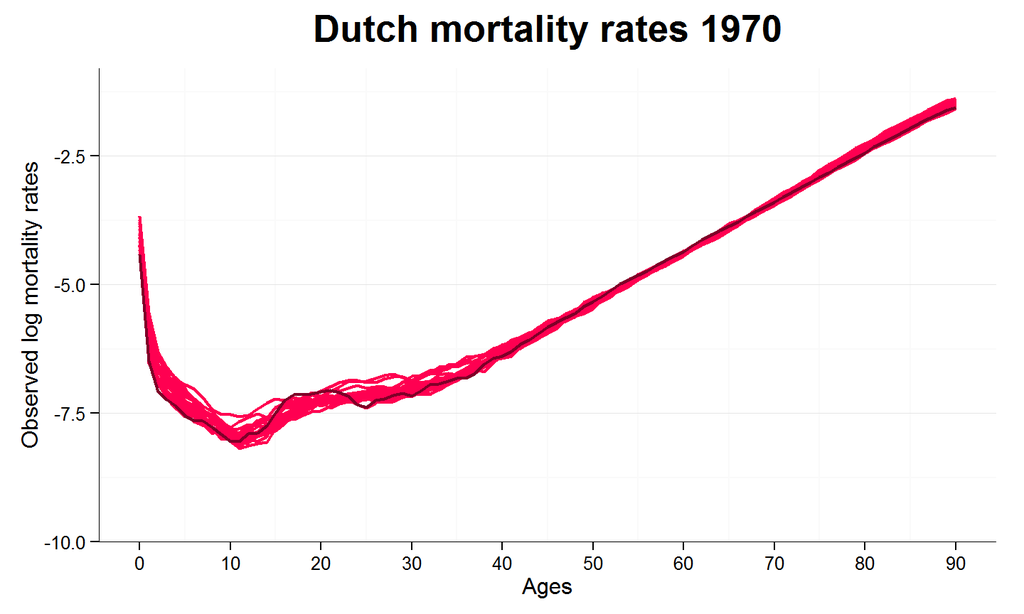

## Predictor

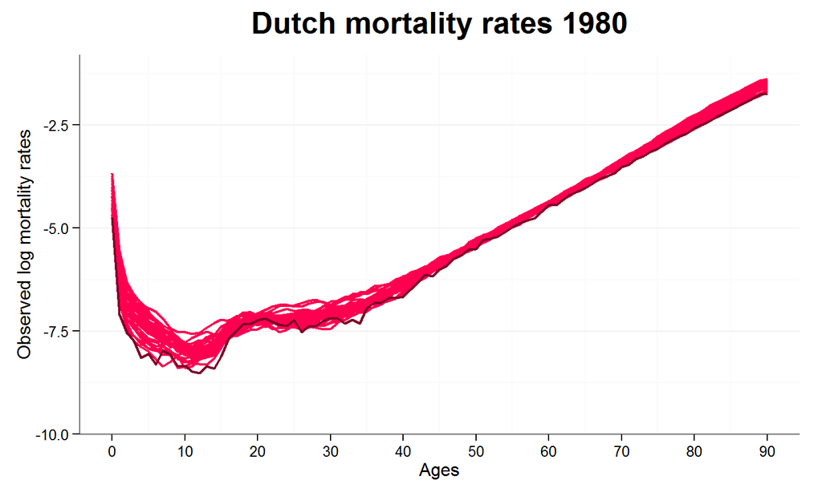

## Predictor

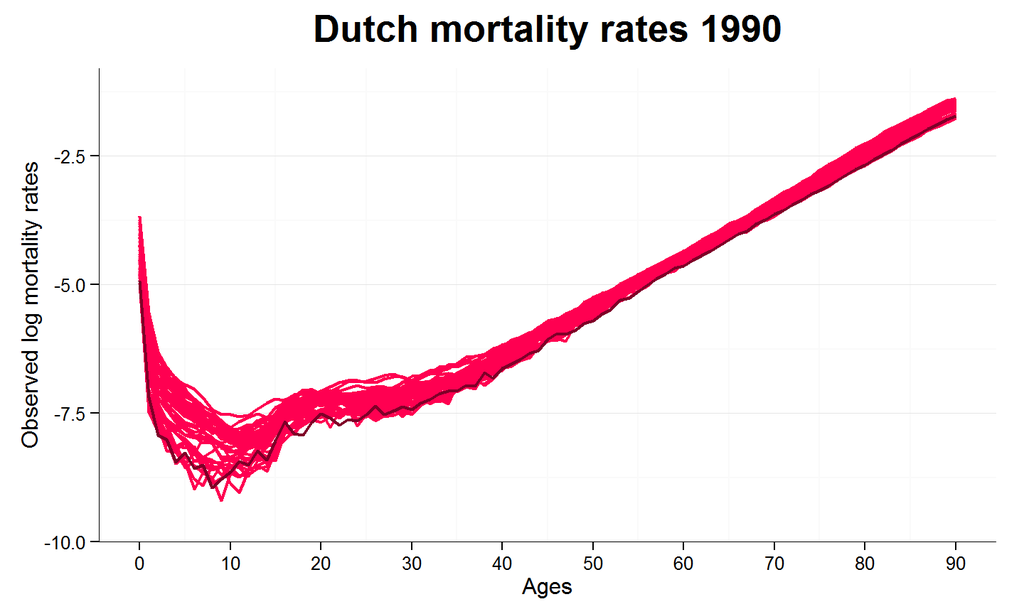

## Predictor

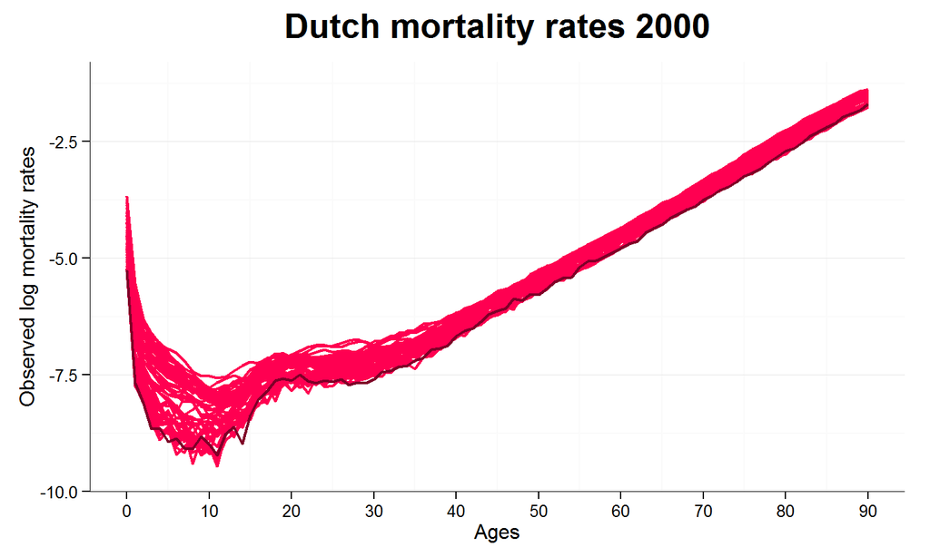

## Predictor

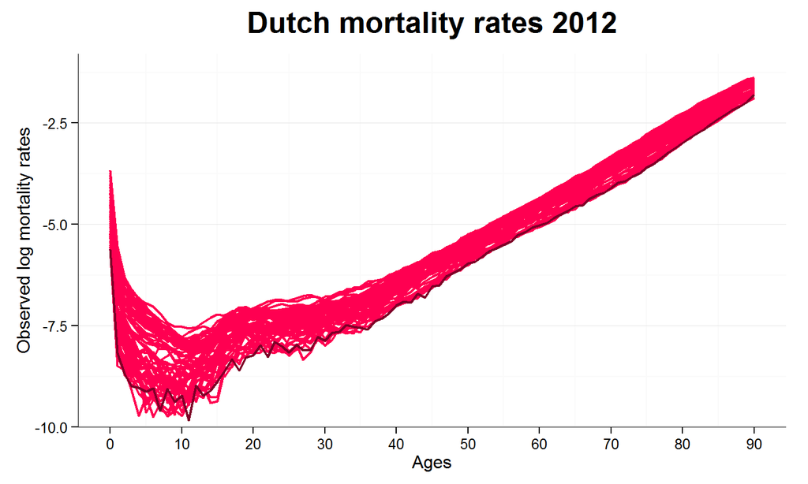

## Predictor

\(\hat{\mu}_{x}(t)\)

## Predictor

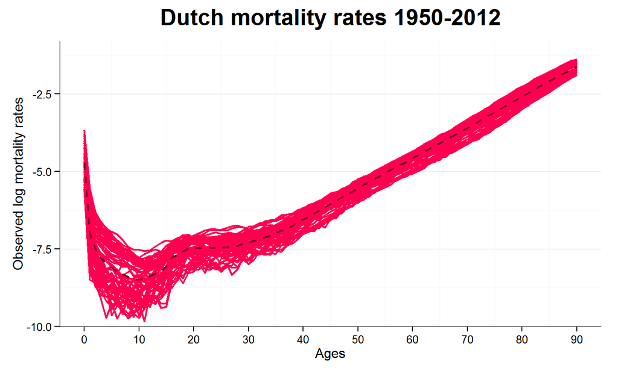

\(\hat{\mu}_{x}(t) = \alpha_{x}\)

## Predictor

\(\hat{\mu}_{x}(t) = \alpha_{x} + \kappa_{t}\)

## Predictor

\(\hat{\mu}_{x}(t) = \alpha_{x} + \beta_{x} \kappa_{t}\)

## Predictor

\(\hat{\mu}_{x}(t) = \alpha_{x} + \sum^{N}_{i=1} \beta^{i}_{x} \kappa^{i}_{t}\) \(N\) - number of age-period terms

## Predictor

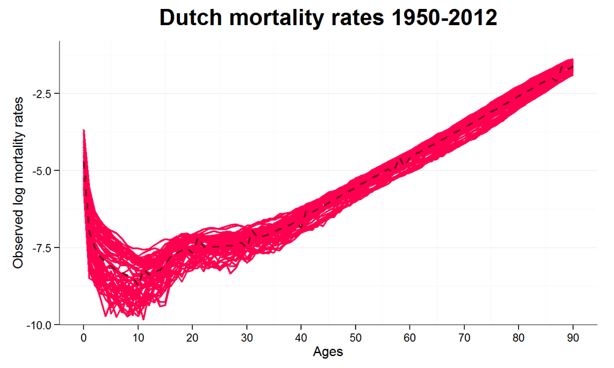

\(\hat{\mu}_{x}(t) = \alpha_{x} + \sum^{N}_{i=1} \beta^{i}_{x} \kappa^{i}_{t} + \gamma_{t-x}\) \(N\) - number of age-period terms

## Predictor

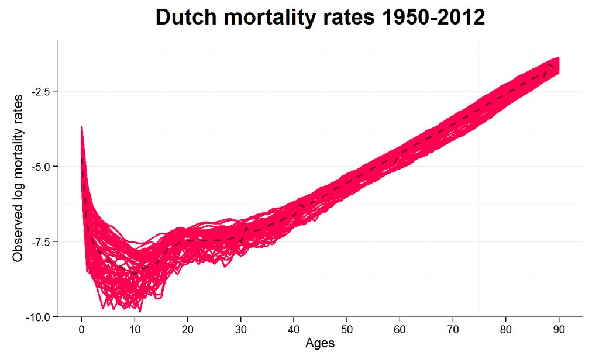

\(\hat{\mu}_{x}(t) = \alpha_{x} + \sum^{N}_{i=1} \beta^{i}_{x} \kappa^{i}_{t} + \beta^{0}_{x} \gamma_{t-x}\) \(N\) - number of age-period terms

## Models Predictor

**Generalised Age-Period-Cohort Stochastic Mortality Models**

- Lee-Carter (LC)

  \(\hat{\mu_{xt}} = \alpha_{x} + \beta^{(1)}_{x} \kappa^{(1)}_{t}\)
- Age-Period-Cohort (APC)

  \(\hat{\mu_{xt}} = \alpha_{x} + \kappa^{(1)}_{t} +\gamma_{t-x}\)
- Cairns-Blake Dowd (CBD)

  \(\hat{\mu_{xt}} = \kappa^{(1)}_{t} + (x-\bar{x})\kappa^{(2)}_{t}\)
- Renshaw and Haberman (RH)

  \(\hat{\mu_{xt}} = \alpha_{x} + \beta^{(1)}_{x} \kappa^{(1)}_{t} + +\gamma_{t-x}\)

## Models Predictor

**Generalised Age-Period-Cohort Stochastic Mortality Models**

- Quadratic CBD with cohort effects M6

  \(\hat{\mu_{xt}} = \kappa^{(1)}_{t} + (x-\bar{x})\kappa^{(2)}_{t} +\gamma_{t-x}\)
- Quadratic CBD with cohort effects M7

  \(\hat{\mu_{t}} = \alpha_{x} + \kappa^{(1)}_{t} + (x-\bar{x})\kappa^{(2)}_{t} + \gamma_{t-x}\)

## Model Comparison

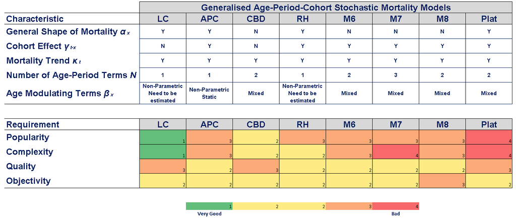

## Random Component

The numbers of deaths \(D_{xt}\) are independent

\(D_{xt}\) follows a Poisson or a Binomial distribution

## Link Function

- Number of link functions possible
- Convenient to use canonical link
  - Log link for Poisson \(\hat{\mu}_{xt} = log\mu_{xt}\)
  - Logit link for Binomial \(\hat{\mu}_{xt} = ln[\mu_{xt}/(1-\mu_{xt})]\)

## Parameter Constraints

- Most stochastic mortality models not identifiable up to a transformation
- Therefore parameter constraints required to ensure unique parameter estimates
- Parameter constraints applied through constraint function

## Stochastic Models

Models sensitive to:

- Historical data
- Assumptions made

Good practice

- Understand and validate data
- Understand models and their assumptions
- Test several methods
- Compare and validate results

## .

**R Workshop**

## R getting started

- Create a new folder and put the R scripts prepared for the workshop there https://github.com/TARF/SMM/raw/master/Case_studies.zip
- Set working directory **Session > Set Working Directory > Choose Directory…** or press **Ctrl+Shift+H** and select the folder or use the console

```r
setwd('<directory name>') # wrapped in ''
## for Windows the path uses / instead \
```

- Install required packages

```r
install.packages(c("demography","StMoMo","rgl",
                   "fanplot", "ggplot2", "gridExtra", "reshape2"))
```

## Case Study

Dutch mortality data from Human Mortality Database

Look at mortality models: LC, APC, CBD, RH, M6-M8, PLAT

BEL and SCR Projection for a portfolio

Open script stmomoNL.R

## Exercises

- Shock in the portfolio: everybody 5 years younger
- Mortality projection based on shorter historical data: 1989 instead 1950
  - Exclude RH model (problems with convergence)

## References

["StMoMO: An R Package for Stochastic Mortality Modelling"](https://cran.r-project.org/web/packages/StMoMo/vignettes/StMoMoVignette.pdf) A.M. Villegas et al.

["Stochastic Modelling of Mortality Risks"](http://dare.uva.nl/cgi/arno/show.cgi?fid=22881) Frankie Gregorkiewicz

["Solvency II Glossary"](http://ec.europa.eu/internal_market/insurance/docs/solvency/impactassess/annex-c08d_en.pdf) CEA and the Groupe Consultatif

["R: The most powerful and most widely used statistical software"](https://www.youtube.com/watch?v=TR2bHSJ_eck&feature=youtu.be) Revolution Analytics